# AI4PH: Federated Learning Tutorial

## Setup

We begin by loading the necessary packages and functions and setting a seed for reproducibility.

```r
# Load packages
suppressPackageStartupMessages({
  library(dplyr)
  library(readr)
  library(skimr)
  library(nnet)
})

# Load functions
source("fl_funs.R")

# Set seed (for reproducibility)
set.seed(123)
```

## Load and process data

Next, we load the simulated cardiovascular disease (CVD) dataset, adding an explicit `site` column to identify the source of each observation. The dataset contains information on patients from three different sites: an urban academic medical center, a suburban practice, and a rural community clinic.

```r
# Load training data
df_train_urban <- read_csv("sim/urban_train.csv", show_col_types = FALSE) %>%
  mutate(site = "Urban Academic")
df_train_suburban <- read_csv("sim/suburban_train.csv", show_col_types = FALSE) %>%
  mutate(site = "Suburban Practice")
df_train_rural <- read_csv("sim/rural_train.csv", show_col_types = FALSE) %>%
  mutate(site = "Rural Community")

# Load testing data
df_test_urban <- read_csv("sim/urban_test.csv", show_col_types = FALSE) %>%
  mutate(site = "Urban Academic")
df_test_suburban <- read_csv("sim/suburban_test.csv", show_col_types = FALSE) %>%
  mutate(site = "Suburban Practice")
df_test_rural <- read_csv("sim/rural_test.csv", show_col_types = FALSE) %>%
  mutate(site = "Rural Community")
```

The first thing we will do is examine the training datasets from our various sites (for simplicity, we will assume the testing datasets are formatted identically).

```r
skim(df_train_urban)
```

Data summary

| Name | df_train_urban |
| --- | --- |
| Number of rows | 200 |
| Number of columns | 8 |
| _______________________ |  |
| Column type frequency: |  |
| character | 3 |
| numeric | 5 |
| ________________________ |  |
| Group variables | None |

**Variable type: character**

| skim_variable | n_missing | complete_rate | min | max | empty | n_unique | whitespace |
| --- | --- | --- | --- | --- | --- | --- | --- |
| gender | 1 | 1.00 | 4 | 6 | 0 | 2 | 0 |
| smoking_status | 7 | 0.96 | 5 | 7 | 0 | 3 | 0 |
| site | 0 | 1.00 | 14 | 14 | 0 | 1 | 0 |

**Variable type: numeric**

| skim_variable | n_missing | complete_rate | mean | sd | p0 | p25 | p50 | p75 | p100 | hist |
| --- | --- | --- | --- | --- | --- | --- | --- | --- | --- | --- |
| age | 0 | 1.00 | 39.52 | 11.91 | 18 | 31 | 40 | 49 | 79 | ▅▇▆▂▁ |
| bmi | 1 | 1.00 | 23.21 | 3.70 | 15 | 21 | 23 | 26 | 32 | ▂▆▇▃▂ |
| systolic_bp | 2 | 0.99 | 106.75 | 16.38 | 80 | 95 | 107 | 117 | 153 | ▆▇▇▃▁ |
| exercise_hrs_per_week | 2 | 0.99 | 2.63 | 2.68 | 0 | 1 | 2 | 4 | 15 | ▇▂▁▁▁ |
| cvd | 0 | 1.00 | 0.17 | 0.38 | 0 | 0 | 0 | 0 | 1 | ▇▁▁▁▂ |

```r
skim(df_train_suburban)
```

Data summary

| Name | df_train_suburban |
| --- | --- |
| Number of rows | 120 |
| Number of columns | 8 |
| _______________________ |  |
| Column type frequency: |  |
| character | 3 |
| numeric | 5 |
| ________________________ |  |
| Group variables | None |

**Variable type: character**

| skim_variable | n_missing | complete_rate | min | max | empty | n_unique | whitespace |
| --- | --- | --- | --- | --- | --- | --- | --- |
| gender | 1 | 0.99 | 4 | 6 | 0 | 2 | 0 |
| smoking_status | 2 | 0.98 | 5 | 7 | 0 | 3 | 0 |
| site | 0 | 1.00 | 17 | 17 | 0 | 1 | 0 |

**Variable type: numeric**

| skim_variable | n_missing | complete_rate | mean | sd | p0 | p25 | p50 | p75 | p100 | hist |
| --- | --- | --- | --- | --- | --- | --- | --- | --- | --- | --- |
| age | 2 | 0.98 | 48.60 | 15.46 | 18 | 36.25 | 49.5 | 61 | 82 | ▅▇▇▇▂ |
| bmi | 1 | 0.99 | 25.95 | 5.35 | 15 | 22.00 | 26.0 | 29 | 37 | ▃▇▇▆▃ |
| systolic_bp | 1 | 0.99 | 112.39 | 18.46 | 80 | 98.50 | 113.0 | 126 | 160 | ▅▆▇▃▁ |
| exercise_hrs_per_week | 1 | 0.99 | 2.21 | 1.97 | 0 | 1.00 | 2.0 | 3 | 12 | ▇▃▂▁▁ |
| cvd | 0 | 1.00 | 0.41 | 0.49 | 0 | 0.00 | 0.0 | 1 | 1 | ▇▁▁▁▆ |

```r
skim(df_train_rural)
```

Data summary

| Name | df_train_rural |
| --- | --- |
| Number of rows | 80 |
| Number of columns | 8 |
| _______________________ |  |
| Column type frequency: |  |
| character | 3 |
| numeric | 5 |
| ________________________ |  |
| Group variables | None |

**Variable type: character**

| skim_variable | n_missing | complete_rate | min | max | empty | n_unique | whitespace |
| --- | --- | --- | --- | --- | --- | --- | --- |
| smoking_status | 1 | 0.99 | 5 | 7 | 0 | 3 | 0 |
| site | 0 | 1.00 | 15 | 15 | 0 | 1 | 0 |
| sex | 1 | 0.99 | 1 | 1 | 0 | 2 | 0 |

**Variable type: numeric**

| skim_variable | n_missing | complete_rate | mean | sd | p0 | p25 | p50 | p75 | p100 | hist |
| --- | --- | --- | --- | --- | --- | --- | --- | --- | --- | --- |
| age | 1 | 0.99 | 59.49 | 14.46 | 27 | 51 | 58 | 70.5 | 85 | ▂▂▇▅▅ |
| bmi | 1 | 0.99 | 26.28 | 6.69 | 15 | 22 | 26 | 31.0 | 40 | ▆▇▇▆▂ |
| systolic_bp | 1 | 0.99 | 112.91 | 20.71 | 80 | 100 | 114 | 125.0 | 181 | ▆▇▆▁▁ |
| exercise_hrs_per_week | 0 | 1.00 | 1.55 | 1.40 | 0 | 1 | 1 | 2.0 | 6 | ▇▃▂▁▁ |
| cvd | 0 | 1.00 | 0.55 | 0.50 | 0 | 0 | 1 | 1.0 | 1 | ▆▁▁▁▇ |

For most variable, we see nothing particularly concerning: a handful of missing values and no obviously wrong values (e.g., an age of 150). A systolic BP of 181 probably counts as a hypertensive crisis, though.

The variables `sex` and `gender` are a problem though, as the former is present only in the Rural dataset and the latter only in the Urban and Suburban datasets.

We can write a function to check the unique values of all categorical variables across all the training datasets.

```r
for (var in c("sex", "gender", "smoking_status")) {
  cat("\nVariable:", var, "\n")
  urban_vals <- sort(unique(df_train_urban[[var]]))
  suburban_vals <- sort(unique(df_train_suburban[[var]]))
  rural_vals <- sort(unique(df_train_rural[[var]]))
  cat("  Urban: ", paste(urban_vals, collapse = ", "), "\n")
  cat("  Suburban: ", paste(suburban_vals, collapse = ", "), "\n")
  cat("  Rural: ", paste(rural_vals, collapse = ", "), "\n")
}
```

```
Variable: sex
  Urban:
  Suburban:
  Rural:  F, M

Variable: gender
  Urban:  Female, Male
  Suburban:  Female, Male
  Rural:

Variable: smoking_status
  Urban:  Current, Former, Never
  Suburban:  Current, Former, Never
  Rural:  Current, Former, Never
```

It looks like the `sex` variable can be renamed and recoded to match the other sites. The `smoking_status` variable is already consistent across sites.

```r
# Rename and recode sex variable at Rural site as gender
recode_gender <- function(df) {
  df %>%
    mutate(
      gender = case_when(
        sex == "M" ~ "Male",
        sex == "F" ~ "Female",
        is.na(sex) ~ NA_character_
      )
    ) %>%
    select(-sex) # drop sex column
}
df_train_rural <- recode_gender(df_train_rural)
df_test_rural  <- recode_gender(df_test_rural)
```

Next, we will deal with bad or missing data. This can be done through a variety of methods, such as imputation, truncation, or exclusion. Remember that in a real-world scenario, steps such as imputation would generally be done on a per-site basis, unless there was explicit coordination on this front between sites (e.g., through a federated process or a simpler form of data exchange).

If we wanted to impute missing data, we could simply use the median (continuous) or modal (categorical) for each variable within each site, or we could use more complicates methods of imputation such as multivariate imputation as implemented in the `mice` package.

For simplicity, in this tutorial we will simply remove the small percentage of rows with missing data (complete case analysis).

```r
df_train_urban <- df_train_urban[complete.cases(df_train_urban), ]
df_train_suburban <- df_train_suburban[complete.cases(df_train_suburban), ]
df_train_rural <- df_train_rural[complete.cases(df_train_rural), ]
df_test_urban <- df_test_urban[complete.cases(df_test_urban), ]
df_test_suburban <- df_test_suburban[complete.cases(df_test_suburban), ]
df_test_rural <- df_test_rural[complete.cases(df_test_rural), ]
```

We will now combine the training datasets into a single data frame, `df_train`, and the testing datasets into `df_test`. This is where we will convert our categorical variables from `character` to `factor` to ensure there is no conflict (e.g., between the order of the levels). The purpose of this is twofold: first, these datasets will be used directly in the pooled analysis, and second, they will be used in modified form for the federated learning analysis. **This is for convenience only and to reduce potential issues with the federated learning function. The federated learning function splits the datasets back into site-specific datasets internally to simulate a true federated setup.** Conceptually, for the federated learning analysis, we can think of this step as coordination between the sites on an agreed-upon schema for the data between sites (e.g., agreeing that “Female” is the reference category for the `gender` variable).

```r
df_train <- bind_rows(df_train_urban, df_train_suburban, df_train_rural)
head(df_train)
```

```
# A tibble: 6 × 8
    age gender   bmi systolic_bp exercise_hrs_per_week smoking_status   cvd
  <dbl> <chr>  <dbl>       <dbl>                 <dbl> <chr>          <dbl>
1    18 Female    26          95                     1 Never              0
2    40 Male      20         127                     1 Never              0
3    46 Male      26         110                     4 Former             0
4    30 Male      24         117                     3 Never              0
5    38 Female    25         108                    10 Former             0
6    43 Female    26         122                     0 Never              0
# ℹ 1 more variable: site <chr>
```

```r
df_test <- bind_rows(df_test_urban, df_test_suburban, df_test_rural)
head(df_test)
```

```
# A tibble: 6 × 8
    age gender   bmi systolic_bp exercise_hrs_per_week smoking_status   cvd
  <dbl> <chr>  <dbl>       <dbl>                 <dbl> <chr>          <dbl>
1    33 Female    17          90                     1 Never              0
2    41 Male      20         108                     7 Former             0
3    49 Female    22         132                     4 Former             0
4    43 Male      22         142                     5 Never              0
5    35 Male      23         105                     2 Never              0
6    46 Female    16          80                     7 Former             1
# ℹ 1 more variable: site <chr>
```

The first thing we will do is convert our categorical variables from `character` to `factor` so they are handled correctly by our summary function and by the modelling functions we will use later. **It is especially important that we also convert the outcome variable, `cvd`, to a factor with levels `c(0, 1)`**, as this ensures that the modelling functions will work properly for a binary classification task.

```r
# Convert categorical variables to factors
# Recall that the first "level" will be used as the reference category in our models
convert_factors <- function(df) {
  df$gender <- factor(df$gender, levels = c("Female", "Male"))
  df$smoking_status <- factor(df$smoking_status, levels = c("Never", "Former", "Current"))
  df$cvd <- factor(df$cvd, levels = c(0, 1))
  df$site <- factor(df$site) # doesn't matter as we will not be using site as a covariate
  return(df)
}
df_train <- convert_factors(df_train)
df_test  <- convert_factors(df_test)
```

Earlier, we observed that the data distributions differ across sites, i.e., the data are not IID across sites. We could verify this statistically if we’d like (e.g., using Kruskal-Wallis test for continuous variables or Chi-squared test for categorical variables).

```r
# Example: Kruskal-Wallis test for continuous variable `age` across sites
kruskal.test(age ~ site, data = df_train)
```

```
    Kruskal-Wallis rank sum test

data:  age by site
Kruskal-Wallis chi-squared = 83.9, df = 2, p-value < 2.2e-16
```

```r
# Example: Chi-squared test for categorical variable `smoking_status` across sites
chisq.test(df_train$smoking_status, df_train$site)
```

```
    Pearson's Chi-squared test

data:  df_train$smoking_status and df_train$site
X-squared = 29.332, df = 4, p-value = 6.691e-06
```

Before we split the data, let’s do a little feature engineering. Suppose we believe BMI has a non-linear effect and want to categorize it for our logistic regression model (but letting our tree-based models handle it naturally). We can create a new variable `bmi_cat` that categorizes BMI into low, medium, and high.

For the federated analysis, this step would be part of defining the schema for the data that all sites agree to use.

```r
# Add BMI categories
add_bmi_cat <- function(df) {
  df <- df %>%
    mutate(
      bmi_cat = case_when(
        bmi < 18.5 ~ "Low",
        bmi >= 18.5 & bmi < 25 ~ "Medium",
        TRUE ~ "High"
      ),
      # Use "Medium" as reference category
      bmi_cat = factor(bmi_cat, levels = c("Medium", "Low", "High"))
    )
  return(df)
}
df_train <- add_bmi_cat(df_train)
df_test  <- add_bmi_cat(df_test)
```

We are now ready to do some model fitting.

## Federated learning

### Logistic regression with FedAvg

```r
fl_lr <- fed_learn(
  df_train,
  df_test,
  target_col = "cvd",
  site_col = "site",
  algorithm = "FedAvg",
  model = "logistic",
  formula = cvd ~ age + gender + bmi_cat + systolic_bp + exercise_hrs_per_week + smoking_status
)
```

```
FedAvg on 3 sites

Site weights:
   Rural Community: 0.201 (75 samples)
  Suburban Practice: 0.299 (112 samples)
  Urban Academic: 0.500 (187 samples)

Training local models and evaluating initial performance...
  Rural Community: initial accuracy = 0.8947
  Suburban Practice: initial accuracy = 0.6897
  Urban Academic: initial accuracy = 0.8958

Aggregating global model coefficients...
Updating local models with global coefficients and evaluating updated performance...
  Rural Community: updated accuracy = 0.8421 (Δ = -0.0526)
  Suburban Practice: updated accuracy = 0.7586 (Δ = +0.0690)
  Urban Academic: updated accuracy = 0.8958 (Δ = +0.0000)

Performance summary:
  Rural Community: Initial = 0.8947, Updated = 0.8421, Δ = -0.0526
  Suburban Practice: Initial = 0.6897, Updated = 0.7586, Δ = +0.0690
  Urban Academic: Initial = 0.8958, Updated = 0.8958, Δ = +0.0000

Overall weighted accuracy: Initial = 0.8339, Updated = 0.8440, Δ = +0.0101
```

We can examine the initial per-site models in the object returned by the `fed_learn()` function.

```r
# Examine initial per-site models
fl_lr$models_initial
```

```
$`Rural Community`

Call:  glm(formula = formula, family = binomial(), data = x$train)

Coefficients:
          (Intercept)                    age             genderMale
             -4.48110                0.03329                0.80732
           bmi_catLow            bmi_catHigh            systolic_bp
              0.53131                0.01694                0.01732
exercise_hrs_per_week   smoking_statusFormer  smoking_statusCurrent
             -0.21937                0.77060                1.77726

Degrees of Freedom: 74 Total (i.e. Null);  66 Residual
Null Deviance:      103.3
Residual Deviance: 86.43    AIC: 104.4

$`Suburban Practice`

Call:  glm(formula = formula, family = binomial(), data = x$train)

Coefficients:
          (Intercept)                    age             genderMale
             -7.56362                0.07436                0.45327
           bmi_catLow            bmi_catHigh            systolic_bp
              0.94906                0.68271                0.01799
exercise_hrs_per_week   smoking_statusFormer  smoking_statusCurrent
              0.02299                0.92371                1.92717

Degrees of Freedom: 111 Total (i.e. Null);  103 Residual
Null Deviance:      151.7
Residual Deviance: 112.9    AIC: 130.9

$`Urban Academic`

Call:  glm(formula = formula, family = binomial(), data = x$train)

Coefficients:
          (Intercept)                    age             genderMale
            -5.121732               0.069082              -0.120588
           bmi_catLow            bmi_catHigh            systolic_bp
             0.751175               0.404685               0.008553
exercise_hrs_per_week   smoking_statusFormer  smoking_statusCurrent
            -0.278813               0.046821               0.818201

Degrees of Freedom: 186 Total (i.e. Null);  178 Residual
Null Deviance:      168
Residual Deviance: 144.1    AIC: 162.1
```

```r
# See per-site model accuracies
fl_lr$accuracy_initial
```

```
  Rural Community Suburban Practice    Urban Academic
        0.8947368         0.6896552         0.8958333
```

We can also examine the coefficients of the FedAvg process, which are used for the updated model:

```r
fl_lr$models_updated[[1]]$coefficients
```

```
          (Intercept)                   age            genderMale
          -5.72452338            0.06348526            0.23733862
           bmi_catLow           bmi_catHigh           systolic_bp
           0.76634366            0.41018782            0.01313736
exercise_hrs_per_week  smoking_statusFormer smoking_statusCurrent
          -0.17651139            0.45456039            1.34262441
```

Now we can can extract the predictions (probabilities and discrete classes) from the federated learning object (these are in the same order as the `df_test` data frame). We can use these to calculate some evaluation metrics for our logistic regression model on the pooled dataset, including the accuracy, sensitivity, specificity, and area under the ROC curve (AUC).

```r
# Extract predictions
df_test$pred_lr_fl <- fl_lr$probabilities_overall_updated
df_test$pred_class_lr_fl <- fl_lr$predictions_overall_updated

# Calculate accuracy, sensitivity/specificity, AUC
acc_lr_fl <- accuracy(
  df_test,
  pred_class_lr_fl, # discrete class predictions
  truth = cvd
)
acc_lr_fl
```

```
# A tibble: 1 × 3
  .metric  .estimator .estimate
  <chr>    <chr>          <dbl>
1 accuracy binary         0.844
```

```r
sensitivity(
  df_test,
  pred_class_lr_fl, # discrete class predictions
  truth = cvd,
  event_level = "second" # use 1 as event
)
```

```
# A tibble: 1 × 3
  .metric     .estimator .estimate
  <chr>       <chr>          <dbl>
1 sensitivity binary         0.677
```

```r
specificity(
  df_test,
  pred_class_lr_fl,
  truth = cvd,
  event_level = "second" # use 1 as event
)
```

```
# A tibble: 1 × 3
  .metric     .estimator .estimate
  <chr>       <chr>          <dbl>
1 specificity binary         0.923
```

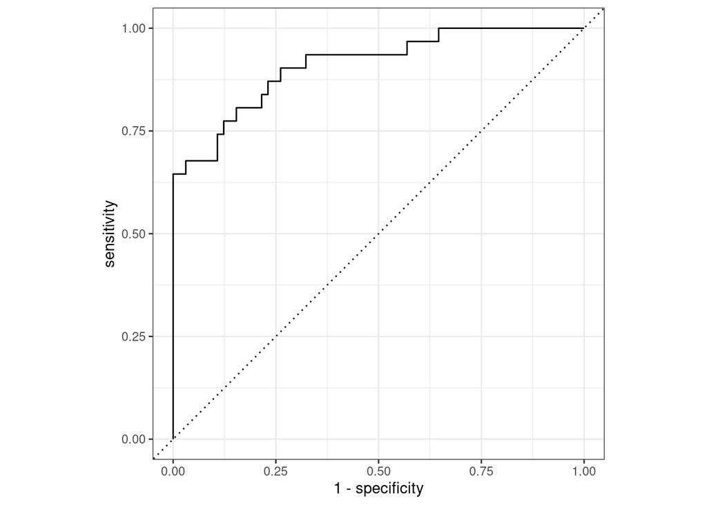

```r
roc_curve(
  df_test,
  pred_lr_fl, # probabilities
  truth = cvd,
  event_level = "second" # use 1 as event
) %>% autoplot()
```

```r
roc_auc(
  df_test,
  pred_lr_fl, # probabilities
  truth = cvd,
  event_level = "second" # use 1 as event
)
```

```
# A tibble: 1 × 3
  .metric .estimator .estimate
  <chr>   <chr>          <dbl>
1 roc_auc binary         0.911
```

See the `yardstick` package for more information on calculating evaluation metrics.

We can also write a custom function to calculate the accuracy with a 95% binomial confidence interval using the `binom.test()` function, in the absence of other methods of calculating confidence intervals for accuracy (e.g., cross-validation or bootstrapping).

```r
# Function: Calculate accuracy with 95% binomial CI
accuracy_ci <- function(data, pred_class, truth) {
  bt <- binom.test(
  sum(data[[pred_class]] == data[[truth]]),
  nrow(data),
  conf.level = 0.95 # using Clopper-Pearson method
  )
  tibble(
  .estimate = bt$estimate,
  lower = bt$conf.int[1],
  upper = bt$conf.int[2]
  )
}

# Recalculate accuracy with confidence interval
acc_lr_fl <- accuracy_ci(
  df_test,
  pred_class = "pred_class_lr_fl",
  truth = "cvd"
)
acc_lr_fl
```

```
# A tibble: 1 × 3
  .estimate lower upper
      <dbl> <dbl> <dbl>
1     0.844 0.755 0.910
```

### Random forest with Distributed Ensemble

```r
# Pass optional parameters to randomForest() function as additional arguments
# See ?randomForest for details on available parameters
fl_rf <- fed_learn(
  df_train,
  df_test,
  target_col = "cvd",
  site_col = "site",
  algorithm = "Distributed Ensemble",
  model = "randomForest",
  formula = cvd ~ age + gender + bmi + systolic_bp + exercise_hrs_per_week + smoking_status,
  ntree = 500, # pass optional parameter
  mtry = 2 # pass optional parameter
)
```

```
Distributed Ensemble: randomForest on 3 sites

Site weights:
   Rural Community: 0.201 (75 samples)
  Suburban Practice: 0.299 (112 samples)
  Urban Academic: 0.500 (187 samples)

Training individual site models and evaluating individual performance...
  Rural Community: initial accuracy = 0.5263
  Suburban Practice: initial accuracy = 0.7586
  Urban Academic: initial accuracy = 0.8333

Evaluating updated performance (weighted ensemble)...
  Rural Community: updated accuracy = 0.7368 (Δ = +0.2105)
  Suburban Practice: updated accuracy = 0.7586 (Δ = +0.0000)
  Urban Academic: updated accuracy = 0.8542 (Δ = +0.0208)

Performance summary:
  Rural Community: Initial = 0.5263, Updated = 0.7368, Δ = +0.2105
  Suburban Practice: Initial = 0.7586, Updated = 0.7586, Δ = +0.0000
  Urban Academic: Initial = 0.8333, Updated = 0.8542, Δ = +0.0208

Overall weighted accuracy: Initial = 0.7494, Updated = 0.8020, Δ = +0.0526
```

```r
# Extract predictions
df_test$pred_rf_fl <- fl_rf$probabilities_overall_updated
df_test$pred_class_rf_fl <- fl_rf$predictions_overall_updated

# Calculate accuracy
acc_rf_fl <- accuracy_ci(
  df_test,
  pred_class = "pred_class_rf_fl", # column name as string
  truth = "cvd" # column name as string
)
acc_rf_fl
```

```
# A tibble: 1 × 3
  .estimate lower upper
      <dbl> <dbl> <dbl>
1     0.802 0.708 0.876
```

### XGBoost with Distributed Ensemble

```r
# Pass optional parameters to xgboost() function as additional arguments
# See ?xgboost for details on available parameters
# The argument `nrounds` is required for xgboost() but defaults to 100 if not specified here.
# Note: The xgboost function requires the data to be in a specific format,
# but the fed_learn() function will handle the conversion for you.
fl_xgb <- fed_learn(
  df_train,
  df_test,
  target_col = "cvd",
  site_col = "site",
  algorithm = "Distributed Ensemble",
  model = "xgboost",
  formula = cvd ~ age + gender + bmi + systolic_bp + exercise_hrs_per_week + smoking_status,
  nrounds = 100 # required argument for xgboost() but defaults to 100 if missing here
)
```

```
Distributed Ensemble: xgboost on 3 sites

Site weights:
   Rural Community: 0.201 (75 samples)
  Suburban Practice: 0.299 (112 samples)
  Urban Academic: 0.500 (187 samples)

Training individual site models and evaluating individual performance...
  Rural Community: initial accuracy = 0.5789
  Suburban Practice: initial accuracy = 0.6552
  Urban Academic: initial accuracy = 0.8125

Evaluating updated performance (weighted ensemble)...
  Rural Community: updated accuracy = 0.6842 (Δ = +0.1053)
  Suburban Practice: updated accuracy = 0.6897 (Δ = +0.0345)
  Urban Academic: updated accuracy = 0.8333 (Δ = +0.0208)

Performance summary:
  Rural Community: Initial = 0.5789, Updated = 0.6842, Δ = +0.1053
  Suburban Practice: Initial = 0.6552, Updated = 0.6897, Δ = +0.0345
  Urban Academic: Initial = 0.8125, Updated = 0.8333, Δ = +0.0208

Overall weighted accuracy: Initial = 0.7186, Updated = 0.7604, Δ = +0.0419
```

```r
# Extract predictions
df_test$pred_xgb_fl <- fl_xgb$probabilities_overall_updated
df_test$pred_class_xgb_fl <- fl_xgb$predictions_overall_updated

# Calculate accuracy
acc_xgb_fl <- accuracy_ci(
  df_test,
  pred_class = "pred_class_xgb_fl",
  truth = "cvd"
)
acc_xgb_fl
```

```
# A tibble: 1 × 3
  .estimate lower upper
      <dbl> <dbl> <dbl>
1     0.760 0.663 0.842
```

## Comparison to pooled datasets

Next, we can proceed to fitting models on the pooled datasets. Here, we use the base fitting functions.

### Logistic regression

```r
# Fit a logistic regression model on the pooled dataset
mod_lr <- glm(
  cvd ~ age + gender + bmi_cat + systolic_bp + exercise_hrs_per_week + smoking_status,
  data = df_train,
  family = "binomial")

# Predict on the test set
df_test$pred_lr_pool <- predict(mod_lr, newdata = df_test, type = "response") # probabilities
df_test$pred_class_lr_pool <- factor(ifelse(df_test$pred_lr_pool >= 0.5, 1, 0), levels = c(0, 1)) # discrete class predictions

# Calculate accuracy
acc_lr_pool <- accuracy_ci(
  df_test,
  pred_class = "pred_class_lr_pool",
  truth = "cvd"
)
acc_lr_pool
```

```
# A tibble: 1 × 3
  .estimate lower upper
      <dbl> <dbl> <dbl>
1     0.823 0.732 0.893
```

### Random forest

```r
# Fit a random forest model on the pooled dataset
mod_rf <- randomForest(
  cvd ~ age + gender + bmi + systolic_bp + exercise_hrs_per_week + smoking_status,
  data = df_train,
  ntree = 500, # optional parameter
  mtry = 2) # optional parameter
df_test$pred_rf_pool <- predict(mod_rf, newdata = df_test, type = "prob")[, 2]
df_test$pred_class_rf_pool <- factor(ifelse(df_test$pred_rf_pool >= 0.5, 1, 0), levels = c(0, 1))

# Calculate accuracy
acc_rf_pool <- accuracy_ci(
  df_test,
  pred_class = "pred_class_rf_pool",
  truth = "cvd"
)
acc_rf_pool
```

```
# A tibble: 1 × 3
  .estimate lower upper
      <dbl> <dbl> <dbl>
1     0.792 0.697 0.868
```

The data for XGBoost requires special preparation. This was handled for us automatically in the federated learning function.

### XGBoost

```r
# Prepare data for XGBoost
xgb_terms <- terms(cvd ~ age + gender + bmi + systolic_bp + exercise_hrs_per_week + smoking_status)
df_train_xgb <- model.matrix(xgb_terms, data = df_train)[, -1, drop = FALSE] # drop intercept
df_test_xgb <- model.matrix(xgb_terms, data = df_test)[, -1, drop = FALSE] # drop intercept
df_train_label <- as.numeric(as.character(df_train$cvd)) # convert factor to numeric (0, 1)
df_test_label <- as.numeric(as.character(df_test$cvd)) # convert factor to numeric (0, 1)

# Fit an XGBoost model on the pooled dataset
mod_xgb <- xgboost(
  data = df_train_xgb,
  label = df_train_label,
  objective = "binary:logistic", # required
  nrounds = 100, # required
  verbose = 0 # suppress output
)
df_test$pred_xgb_pool <- predict(mod_xgb, newdata = df_test_xgb)
df_test$pred_class_xgb_pool <- factor(ifelse(df_test$pred_xgb_pool >= 0.5, 1, 0), levels = c(0, 1))

# Calculate accuracy
acc_xgb_pool <- accuracy_ci(
  df_test,
  pred_class = "pred_class_xgb_pool",
  truth = "cvd"
)
acc_xgb_pool
```

```
# A tibble: 1 × 3
  .estimate lower upper
      <dbl> <dbl> <dbl>
1     0.771 0.674 0.850
```

### Neural network

We can also fit a simple neural network model on the pooled dataset using the `nnet` package. This is not supported by the federated learning function, but we can still compare the pooled analysis to the other models.

```r
# Fit a neural network model on the pooled dataset
mod_nn <- nnet(
  cvd ~ age + gender + bmi + systolic_bp + exercise_hrs_per_week + smoking_status,
  data = df_train,
  size = 5, # important parameter
  maxit = 200,
  trace = FALSE # suppress output
)
df_test$pred_nn_pool <- predict(mod_nn, newdata = df_test, type = "raw")
df_test$pred_class_nn_pool <- factor(ifelse(df_test$pred_nn_pool >= 0.5, 1, 0), levels = c(0, 1))

# Calculate accuracy
acc_nn_pool <- accuracy_ci(df_test, pred_class = "pred_class_nn_pool", truth = "cvd")
acc_nn_pool
```

```
# A tibble: 1 × 3
  .estimate lower upper
      <dbl> <dbl> <dbl>
1     0.677 0.574 0.769
```

Below is a final comparison of the test accuracy between the federated learning models and the pooled dataset models.

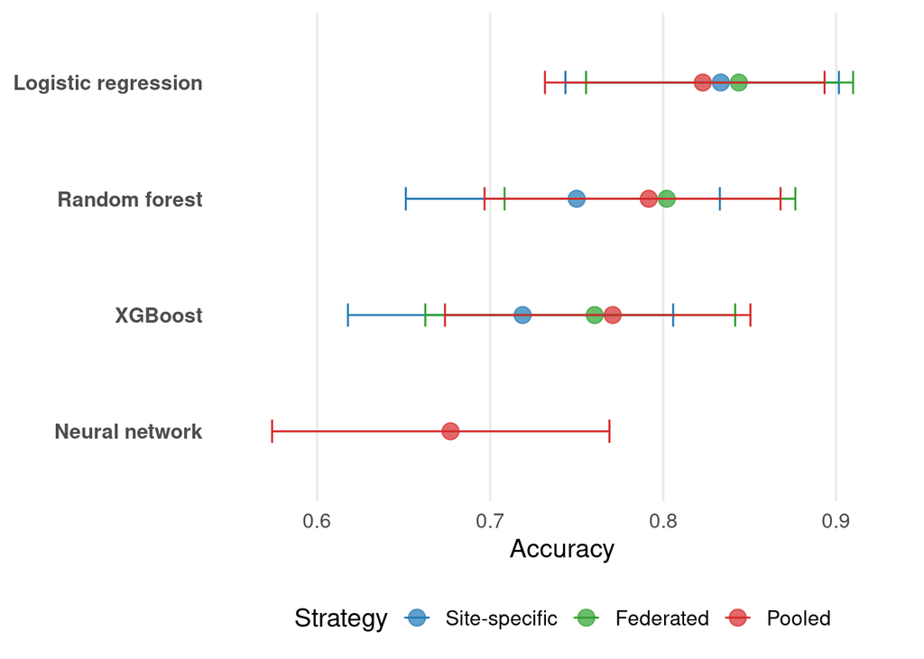

```r
# Calculate initial accuracies with CIs for federated learning models
df_test$pred_class_lr_fl_initial <- fl_lr$predictions_overall_initial
acc_lr_fl_initial <- accuracy_ci(df_test, pred_class = "pred_class_lr_fl_initial", truth = "cvd")
df_test$pred_class_rf_fl_initial <- fl_rf$predictions_overall_initial
acc_rf_fl_initial <- accuracy_ci(df_test, pred_class = "pred_class_rf_fl_initial", truth = "cvd")
df_test$pred_class_xgb_fl_initial <- fl_xgb$predictions_overall_initial
acc_xgb_fl_initial <- accuracy_ci(df_test, pred_class = "pred_class_xgb_fl_initial", truth = "cvd")

# Combine accuracies into a data frame for comparison
accuracy_comparison <- data.frame(
  Model = rep(c(
    "Logistic regression", "Random forest", "XGBoost"
  ), times = 3),
  Strategy = rep(c("Site-specific", "Federated", "Pooled"), each = 3),
  Accuracy = c(
    acc_lr_fl_initial$.estimate,
    acc_rf_fl_initial$.estimate,
    acc_xgb_fl_initial$.estimate,
    acc_lr_fl$.estimate,
    acc_rf_fl$.estimate,
    acc_xgb_fl$.estimate,
    acc_lr_pool$.estimate,
    acc_rf_pool$.estimate,
    acc_xgb_pool$.estimate
  ),
  lower = c(
    acc_lr_fl_initial$lower,
    acc_rf_fl_initial$lower,
    acc_xgb_fl_initial$lower,
    acc_lr_fl$lower,
    acc_rf_fl$lower,
    acc_xgb_fl$lower,
    acc_lr_pool$lower,
    acc_rf_pool$lower,
    acc_xgb_pool$lower
  ),
  upper = c(
    acc_lr_fl_initial$upper,
    acc_rf_fl_initial$upper,
    acc_xgb_fl_initial$upper,
    acc_lr_fl$upper,
    acc_rf_fl$upper,
    acc_xgb_fl$upper,
    acc_lr_pool$upper,
    acc_rf_pool$upper,
    acc_xgb_pool$upper
  )
)

# Add pooled neural network model
accuracy_comparison <- rbind(
  accuracy_comparison,
  data.frame(
    Model = "Neural network",
    Strategy = "Pooled",
    Accuracy = acc_nn_pool$.estimate,
    lower = acc_nn_pool$lower,
    upper = acc_nn_pool$upper
  )
)

# Define factor levels for plotting
accuracy_comparison$Model <- factor(accuracy_comparison$Model, levels = rev(
  c(
    "Logistic regression",
    "Random forest",
    "XGBoost",
    "Neural network"
  )
))
accuracy_comparison$Strategy <- factor(accuracy_comparison$Strategy,
                                       levels = c("Site-specific", "Federated", "Pooled"))

# Plot
ggplot(accuracy_comparison,
       aes(x = Accuracy, y = Model, colour = Strategy)) +
  geom_point(size = 4, alpha = 0.7) +
  geom_errorbarh(aes(xmin = lower, xmax = upper), height = 0.2) +
  scale_colour_manual(values = c(
    "Site-specific" = "#1f77b4",
    "Federated" = "#2ca02c",
    "Pooled" = "#d62728"
  )) +
  theme_minimal(base_size = 14) +
  labs(x = "Accuracy", y = NULL, colour = "Strategy") +
  theme(
    legend.position = "bottom",
    plot.title = element_text(hjust = 0.5, face = "bold", size = 16),
    axis.text.y = element_text(face = "bold"),
    panel.grid.major.y = element_blank(),
    panel.grid.minor = element_blank()
  ) +
  scale_x_continuous(expand = expansion(mult = c(0.1, 0.1)))
```

## Additional evaluation

We can do any number of other analyses, such as looking at fairness metrics. We can look at either subgroup fairness (i.e., fairness across different demographic groups within the dataset) or participation fairness (i.e., fairness across different clients/sites). For illustration, let’s calculate some metrics on the FedAvg logistic regression model.

```r
# Fairness between subgroups: accuracy by gender
df_test %>%
  group_by(gender) %>%
  accuracy(pred_class_lr_fl, truth = cvd)
```

```
# A tibble: 2 × 4
  gender .metric  .estimator .estimate
  <fct>  <chr>    <chr>          <dbl>
1 Female accuracy binary         0.78
2 Male   accuracy binary         0.913
```

```r
# Fairness between clients (sites)

# Jain's fairness index (1 = perfect fairness) on site-specific accuracies
site_acc <- df_test %>%
  group_by(site) %>%
  accuracy(truth = cvd, estimate = pred_class_lr_fl) %>%
  pull(.estimate)
n_sites <- length(site_acc)
jain_index <- (sum(site_acc)^2) / (n_sites * sum(site_acc^2))
site_acc
```

```
[1] 0.8421053 0.7586207 0.8958333
```

```r
jain_index
```

```
[1] 0.995419
```

```r
# Predicted positive rate: (TP + FP) / Total sample size (by site)
ppr_site <- df_test %>%
  group_by(site) %>%
  summarize(PPR = mean(pred_class_lr_fl == 1))
ppr_site
```

```
# A tibble: 3 × 2
  site                 PPR
  <fct>              <dbl>
1 Rural Community   0.789
2 Suburban Practice 0.310
3 Urban Academic    0.0417
```

```r
# False discovery rate: FP / (TP + FP) (by site)
fdr_site <- df_test %>%
  group_by(site) %>%
  summarize(FDR = sum(pred_class_lr_fl == 1 &
                        cvd == 0) / sum(pred_class_lr_fl == 1))
fdr_site
```

```
# A tibble: 3 × 2
  site                FDR
  <fct>             <dbl>
1 Rural Community   0.2
2 Suburban Practice 0.222
3 Urban Academic    0
```

```r
# Prevalence by site: % of positive cases (by site)
prev_site <- df_test %>%
  group_by(site) %>%
  summarize(Prevalence = mean(cvd == 1))
prev_site
```

```
# A tibble: 3 × 2
  site              Prevalence
  <fct>                  <dbl>
1 Rural Community        0.632
2 Suburban Practice      0.414
3 Urban Academic         0.146
```

Something else we can do is compare parameter estimates between strategies, say for the term for “Male” in the logistic regression model:

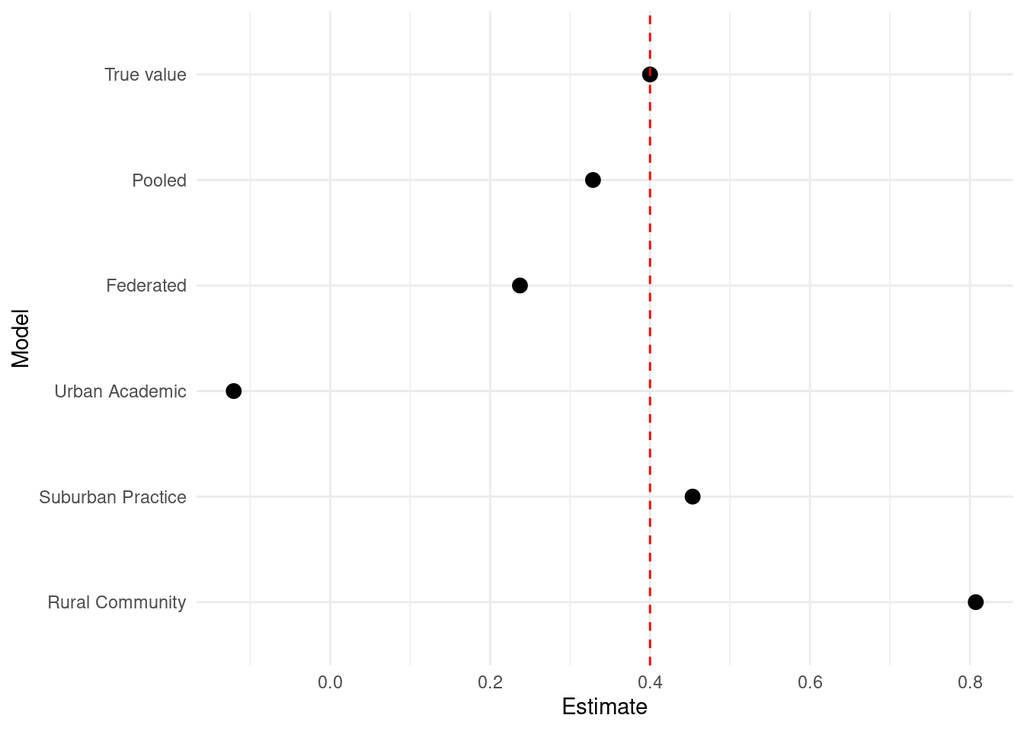

```r
gender_est <- tibble(
  Model = c(fl_lr$site_names, "Federated", "Pooled", "True value"),
  Estimate = c(
    sapply(fl_lr$models_initial, \(x) x$coefficients["genderMale"]), # sites
    fl_lr$models_updated[[1]]$coefficients["genderMale"], # federated
    mod_lr$coefficients["genderMale"], # pooled model
    0.4 # true value from simulation
  )
)
gender_est$Model <- factor(
  gender_est$Model, levels = c(fl_lr$site_names, "Federated", "Pooled", "True value"))
ggplot(gender_est, aes(x = Estimate, y = Model)) +
  geom_point(size = 3) +
  geom_vline(xintercept = 0.4, linetype = "dashed", color = "red") +
  labs(
    x = "Estimate",
    y = "Model"
  ) +
  theme_minimal()
```